# Interagency Ecological Program: Discrete water quality data from the Sacramento River floodplain and tidal slough, collected by the Yolo Bypass Fish Monitoring Program, 1998 - Present

## Abstract

1. Collect baseline data on water quality, chlorophyll, lower trophic level biota, and fish in the Yolo Bypass to monitor spatial and temporal changes in trends and abundance.
2. Analyze and communicate Yolo Bypass data with stakeholders and the scientific and management communities to address pertinent management related questions.
3. Provide technical expertise on Yolo Bypass aquatic ecology and monitoring and sampling methods.

Specifically, the objectives of the water quality monitoring are to:

1. Examine spatial and temporal trends in water quality.
2. Examine the relationship between water quality and biological observations.

## Keywords

| Yolo Bypass |
| --- |
| San Francisco Estuary |
| Sacramento-San Joaquin Delta |
| Yolo Bypass Fish Monitoring Program |
| California Department of Water Resources |
| Interagency Ecological Program |
| tidal slough |
| water quality |
| nutrients |
| chlorophyll |
| cations |
| anions |

## Personnel

#### Creators

| givenName | surName | organization | electronicMailAddress | orcid | role |
| --- | --- | --- | --- | --- | --- |
|  | Interagency Ecological Program (IEP) |  |  |  | Creator |
| Nicole | Kwan | California Department of Water Resources | Nicole.kwan@water.ca.gov | 0000-0003-1178-7788 |  |
| Mallory | Bedwell | California Department of Water Resources | mallory.bedwell@water.ca.gov | 0000-0001-9553-6032 | Database Manager, Field crew, Data contact |

#### Contacts

| givenName | surName | organization | electronicMailAddress | orcid | role |
| --- | --- | --- | --- | --- | --- |
| Nicole | Kwan | California Department of Water Resources | Nicole.kwan@water.ca.gov | 0000-0003-1178-7788 |  |
| Mallory | Bedwell | California Department of Water Resources | mallory.bedwell@water.ca.gov | 0000-0001-9553-6032 | Database Manager, Field crew, Data contact |

#### Associated Parties

| givenName | surName | organization | electronicMailAddress | orcid | role |
| --- | --- | --- | --- | --- | --- |
| Nicole | Kwan | California Department of Water Resources | Nicole.Kwan@water.ca.gov | 0000-0003-1178-7788 | Creator, Associate, Data contact, Field crew |
| Jesse | Adams | California Department of Water Resources | Jesse.Adams@water.ca.gov | 0000-0002-0739-8782 | Field crew |
| Mallory | Bedwell | California Department of Water Resources | Mallory.Bedwell@water.ca.gov | 0000-0001-9553-6032 | Field crew |
| Naoaki | Ikemiyagi | California Department of Water Resources | Naoaki.Ikemiyagi@water.ca.gov |  | Field crew |
| Catarina | Pien | California Department of Water Resources | Catarina.Pien@water.ca.gov | 0000-0003-4427-6300 | Database Manager, Field crew, Data contact |
| JT | Robinson | California Department of Water Resources | James.robinson@water.ca.gov |  | Field Crew |
| Allison | Brady | California Department of Water Resources | Allison.brady@water.ca.gov |  | Field Crew |
| Parisa | Farman | California Department of Water Resources | Parisa.farman@water.ca.gov |  | Field Crew |
| Emily | Hubbard | California Department of Water Resources | Emily.hubbard@water.ca.gov |  | Field Crew |
| Brian | Schreier | California Department of Water Resources | Brian.Schreier@water.ca.gov | 0000-0002-5075-3946 | Associate |
| Ted | Sommer | California Department of Water Resources | Ted.Sommer@water.ca.gov |  | Associate |
| Louise | Conrad | California Department of Water Resources | Louise.Conrad@deltacouncil.ca.gov |  | Associate |

## Geographic Coverage

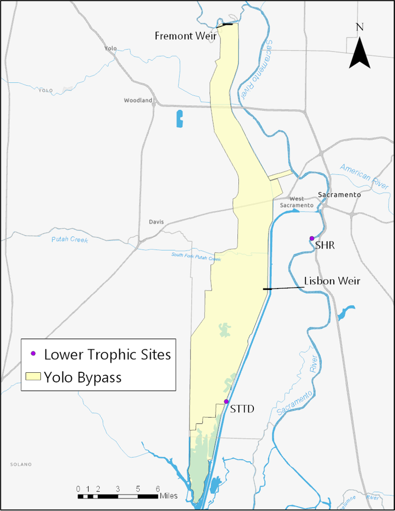

**Yolo Bypass tidal slough and seasonal floodplain in Sacramento, California, USA**

- North bounding coordinates (decimal degrees): 38.79395205
- South bounding coordinates (decimal degrees): 38.23466149
- East bounding coordinates (decimal degrees): -121.5368316
- West bounding coordinates (decimal degrees): - 121.8073699

## Methods

**Water Quality**

Water quality parameters are recorded at the start of each sampling event. Water temperature (degrees Celsius), electrical conductivity (microSiemens/cm), specific conductance (microSiemens/cm), pH, dissolved oxygen (mg/L), and turbidity (FNU) are sampled with a YSI ProDSS handheld meter. Turbidity values are averaged over three readings. Secchi depth is measured in the shade. Light attenuation (subsurface irradiance) is measured with a light meter (LI-COR LI-250A) at the surface, and at 75%, 50%, 25%, and 1% of the surface reference value in the water. The corresponding depth and measured micromoles are noted. Tide, condition of sampling (condition code), Microcystis level, and weather are also recorded with water quality parameters. Please see the YBFMP SOP on Lower Trophic Sample Collection for more details. Water Collection and Filtration Water quality samples are collected using a van dorn. Collection bottles are rinsed three times with sample water before being filled and are stored in a cooler with ice while being transported to the laboratory for filtration. For each sample of chlorophyll a and pheophytin a, between 80-500 mL of sample water is passed through a 47 mm diameter glass fiber filter with a 1.0 m pore size at a pressure of 10 inches of mercury. After filtration, the filters are immediately frozen and transported to DWR’s Bryte Laboratory for analysis within 48 hours of collection (Standard Methods, 19th edition).

Orthophosphate (dissolved), dissolved nitrite + nitrate, dissolved organic nitrogen, dissolved calcium, dissolved chloride, total dissolved solids, and dissolved silica surface are filtered immediately after returning to the laboratory. The samples are filtered through a 0.45 µm pore size mixed cellulous ester membrane filter into one-pint polyethylene bottles, one of the bottles being an actual sample bottle turned into Bryte for analysis and the other being a designated filtration bottle which is rinsed between sites that are being filtered. The filtered water either remains in the one-pint sample bottle or is transferred from the designated filtration bottle to acidified half pint bottles (one with HNO3 and one with H2SO4). All waters samples are stored in the refrigerator and the chlorophyll filter samples are stored in the freezer. All samples are then transported to Bryte Laboratory within 48 hours for analysis.

**Sample Processing and Tracking**

**Sample Tracking**

Samples are tracked using an internal system called FLIMS. A chain of custody (COC) listing sample number, date, time, location, and study/project is sent to Byte Labs, who check that all samples are accounted for and turned in at the correct temperature. Signatures are required of both the person responsible for dropping off the samples, and the person receiving it.

**Contractor**

Since July 2009 (see historical changes for more information)

DWR Bryte Labs

1450 Riverbank Road

West Sacramento, CA 95605

916 376-1959

https://water.ca.gov/Programs/Environmental-Services/Water-Quality-Monitoring-And-Assessment

**Quality Assurance and Control**

**Instrument Specifications**

All YSI ProDSS instrumentation is specified in the ProDSS Manual.

All laboratory instrumentation is listed in the Bryte Lab Quality Manual.

**Calibrations**

YSIs are calibrated for Specific Conductance, pH, Dissolved Oxygen, and turbidity monthly. YSI temperature readings are verified twice per year: once using a 5-point validation and once using a 2-point validation. Please see the YBFMP SOP on ProDSS Calibration for more detail. Prior to sample analysis of conventional and inorganic constituents in water, external calibrations will be made using 3 - 5 standards that cover the range of sample concentrations. The lowest standard will be at or near the Method Detection Limit (MDL). Linear regression will be <0.995 or better. Calibration verification will be run after every 20 samples after the initial calibration and will use a standard source that is different from that used for the initial calibration. Acceptable recovery for conventional analytes is 80 - 120% and for inorganic analytes is 90 – 110%.

See Bryte Chemical Laboratory Quality Manual for additional details.

**Replicates/Duplicates/Blanks**

Equipment blanks - A blank is created for each day of sampling for a subset of nutrient samples, for a total of two equipment blanks. DI water is used to rinse sampling equipment, and then the equipment is filled with DI water and distributed for filtering or filling non-filtered bottles. Blanks are run for: dissolved ammonia, dissolved orthophosphate, dissolved nitrate + nitrate, total kjeldahl nitrogen, and total phosphorus. Replicates - A replicate chlorophyll sample is taken for each site. The same amount of sample water as the parent sample is filtered to create this replicate sample.

Laboratory Control Samples – Laboratory control samples (LCS) provide bias information about a laboratory’s ability to perform acceptable analyses on a clean matrix with the chosen methods. The LCS will be prepared by the laboratory using an aliquot of the clean matrix (e.g., water, sediment, or tissue with no detectable levels of the target analytes) that is spiked with the analytes at known concentrations. The lab results must be within 80-120% recovery or control limits based on 3 times the standard deviation of a lab’s actual method recoveries for the target analytes to be acceptable.

Matrix Spikes – Matrix Spikes (MS) provide bias information on sample preparation and analysis. MS will be used to verify that the lab can determine if the sample matrix is causing either a positive or negative bias on sample results. MS samples will be prepared by the laboratory using an aliquot of the sample matrix (e.g., water sediment, or tissue) that is spiked with the analytes at known concentrations. The lab results must be within 80-120% recovery or control limits based on 3 times the standard deviation of a lab’s actual method recoveries for the target analytes to be acceptable.

Matrix Spike Duplicates – Matrix spike duplicates (MSD) provide precision information on sample preparation and analysis. The laboratory will prepare separate spiked matrix samples (MS) for analysis. Acceptable lab results for bias are the same as described for matrix spikes. The duplicate values must have a RPD of less than 25% to be acceptable.

Laboratory Duplicates – Laboratory duplicates provide precision information on the analytical methods with the target analytes. The laboratory will generate the duplicate samples by splitting one sample into two parts, each of which will be analyzed separately. The duplicate values must have an RPD of less than 25% to be acceptable.

**Data Quality Control**

Three levels of quality control are conducted on field data:

Field data are checked by someone other than the data recorder prior to leaving each field site

Datasheets are checked while being entered into the Microsoft Access database, which has customized error-checking and data validation checks

A separate DWR staff member compares data from original field sheets to data entered into the database

DWR’s Field and Laboratory Information Management System (FLIMS) is used to track water quality field and lab data from collection in the field to final use and storage. Prior to each monthly water quality run, FLIMS is used to generate the paperwork (sample identification numbers, labels, chain of custody sheets, etc.) for each field run. The data collected in the field is recorded on field sheets and is typically entered into FLIMS the next day or before samples are submitted to Bryte Lab. Staff at Bryte Lab enters laboratory data directly in FLIMS that is uploaded to the Water Data Library (WDL) when all the data for one field day has been entered. If there is missing field and lab data, discrepancies between data on field sheets and WDL, or the data does not meet quality objectives, the Lower Tropic Lead is notified and corrections are made, or the data is flagged appropriately.

**Notes on Data Quality:**

Please see the historical changes section for changes in sampling methods.

**Archiving**

Samples are disposed of once analysis is complete.

Data can be accessed on the Department of Water Resources Water Data Library: https://wdlbeta.water.ca.gov/Map.aspx

**Historical Changes**

**Methods:**

From May 2019 until November 2020: 0.45 µm MCE filters used for nutrient filtration (NO2+NO3, O-Phos, NH3, DON) were soaked in DI water for at least 4 hours before use. The water was changed after filters had soaked for an hour, and the hour soaking was repeated a total of 4 times.

11/19/20: Bryte updated preservation methods for some constituents. TKN, TPhos, NO2+NO3, O-Phos, NH3, and DON were previously stored in unacidified half pint bottles and frozen. The new protocol is to add 250 mLs of sample water into a bottle with H2SO4 and to store at 5°C.

June 2021- creation of the blank sample water was standardized. Previously a sample of DI from the lab faucet was filtered. Now the DI is passed through whichever sampling vessel was used (churn splitter or van dorn) and then added to a designated blank 1L Nalgene bottle.

June 2021- the filter used to filter the DOC sampled changed from a combusted 1 µm glass fiber filter to a 0.45 µm MCE filter. Use of a glass filtering flask and a vacuum pump was also added to the DOC filtering protocol.

October 2021- water grabs in the field are now standardized to use the van dorn in order to take a homogenized sample.

**Methods References**

AEU: DWR-6-SOP-024_v1.1_YSI ProDSSCalibration

AEU/Bryte: DES-1-MNL-001Bryte Lab Quality Manual version 4.0

AEU: DWR-6-SOP-015_v1.7_LowerTrophicSampleCollection

## License

This information is released under the [Creative Commons license - Attribution - CC BY](https://creativecommons.org/licenses/by/4.0/). The consumer of these data (“Data User” herein) is required to cite it appropriately in any publication that results from its use. The Data User should realize that these data may be actively used by others for ongoing research and that coordination may be necessary to prevent duplicate publication. The Data User is urged to contact the authors of these data if any questions about methodology or results occur. Where appropriate, the Data User is encouraged to consider collaboration or co-authorship with the authors. The Data User should realize that misinterpretation of data may occur if used out of context of the original study. While substantial efforts are made to ensure the accuracy of data and associated documentation, complete accuracy of data sets cannot be guaranteed. All data are made available “as is.” The Data User should be aware, however, that data are updated periodically, and it is the responsibility of the Data User to check for new versions of the data. The data authors and the repository where these data were obtained shall not be liable for damages resulting from any use or misinterpretation of the data. Thank you.

## Funding

This project was funded by the State Water Project

## Water Quality Table

#### Variables

| attributeName | attributeDefinition | unit |
| --- | --- | --- |
| SampleCode | sample identifier code | NA |
| PhysicalDataID | physical data identifier | NA |
| StationCode | station identifier code | NA |
| StationNumber | station number | NA |
| Datetime | date and time of measurement | NA |
| Date | date of measurement | NA |
| Year | year of measurement | NA |
| Month | month of measurement | NA |
| MonthAbb | month abbreviation | NA |
| Tide | tide at time of measurement | NA |
| Microcystis | visual rating of Microcystis in sampled body | NA |
| Secchi | secchi disk depth | meter |
| WaterTemp | water temperature | celsius |
| Conductivity | water conductivity | microSeimensPerCentimeter |
| SpecificConductance | water specific conductance | microSeimensPerCentimeter |
| DO | dissolved oxygen concentration in water | milligramsPerLiter |
| pH | pH value of water | dimensionless |
| Turbidity | turbidity of water | nephelometricTurbidityUnit |
| Flag_PQC | data flag | NA |
| Comment_PQC | data comments | NA |

#### Preview

| SampleCode | PhysicalDataID | StationCode | StationNumber | Datetime | Date | Year | Month | MonthAbb | Tide | Microcystis | Secchi | WaterTemp | Conductivity | SpecificConductance | DO | pH | Turbidity | Flag_PQC | Comment_PQC |
| --- | --- | --- | --- | --- | --- | --- | --- | --- | --- | --- | --- | --- | --- | --- | --- | --- | --- | --- | --- |
| NA | 93 | SHR | A0200000 | 1998-02-03 09:13:00 | 1998-02-03 | 1998 | 2 | Feb | NA | NA | NA | NA | NA | NA | NA | NA | NA | NA |  |
| NA | 94 | SHR | A0200000 | 1998-02-04 10:30:00 | 1998-02-04 | 1998 | 2 | Feb | NA | NA | NA | NA | NA | NA | NA | NA | NA | NA |  |
| NA | 95 | SHR | A0200000 | 1998-02-11 09:22:00 | 1998-02-11 | 1998 | 2 | Feb | NA | NA | NA | 9.4 | NA | NA | NA | NA | NA | NA |  |
| NA | 96 | SHR | A0200000 | 1998-02-17 09:43:00 | 1998-02-17 | 1998 | 2 | Feb | NA | NA | NA | 10.0 | NA | NA | NA | NA | NA | NA |  |
| NA | 97 | SHR | A0200000 | 1998-02-24 10:03:00 | 1998-02-24 | 1998 | 2 | Feb | NA | NA | NA | NA | NA | NA | NA | NA | NA | NA |  |
| NA | 98 | SHR | A0200000 | 1998-03-04 09:46:00 | 1998-03-04 | 1998 | 3 | Mar | NA | NA | NA | 11.7 | NA | NA | NA | NA | NA | NA |  |

## Chlorophyll/Nutrient Table

#### Variables

| attributeName | attributeDefinition | unit |
| --- | --- | --- |
| Station | station identifier | NA |
| Latitude | latitude of station | degree |
| Longitude | longitude of station | degree |
| Datetime | date and time of measurement | NA |
| Notes | notes about sample | NA |
| SampleCode | sample identifier | NA |
| Chlorophyll | chlorophyll concentration | microgramPerLiter |
| Pheophytin | pheophytin concentration | microgramPerLiter |
| DissAmmonia_Sign | dissolved ammonia sign | NA |
| DissAmmonia | dissolved ammonia concentration | milligramsPerLiter |
| DissCalcium | dissolved calcium concentration | milligramsPerLiter |
| DissChloride | dissolved chloride concentration | milligramsPerLiter |
| DissNitrateNitrite_Sign | dissolved nitrate sign | NA |
| DissNitrateNitrite | dissolved nitrate concentration | milligramsPerLiter |
| DOC | dissolved organic carbon | milligramsPerLiter |
| TOC | total organic carbon | milligramsPerLiter |
| DON | dissolved organic nitrogen | milligramsPerLiter |
| DissOrthophos_Sign | dissolved orthophosphate sign | NA |
| DissOrthophos | dissolved orthophosphate | milligramsPerLiter |
| TotPhos | total phosphate | milligramsPerLiter |
| DissSilica | dissolved silica | milligramsPerLiter |
| TDS | total dissolved solids | milligramsPerLiter |
| TSS | total suspended solids | milligramsPerLiter |
| VSS | volatile suspended solids | milligramsPerLiter |
| TKN | total kjedahl nitrogen | milligramsPerLiter |
| Year | year of measurement | NA |
| WY | water year | NA |
| Month | month of measurement | NA |

#### Preview

| Station | Latitude | Longitude | Datetime | Notes | SampleCode | Chlorophyll | Pheophytin | DissAmmonia_Sign | DissAmmonia | DissCalcium | DissChloride | DissNitrateNitrite_Sign | DissNitrateNitrite | DOC | TOC | DON | DissOrthophos_Sign | DissOrthophos | TotPhos | DissSilica | TDS | TSS | VSS | TKN | Year | WY | Month |
| --- | --- | --- | --- | --- | --- | --- | --- | --- | --- | --- | --- | --- | --- | --- | --- | --- | --- | --- | --- | --- | --- | --- | --- | --- | --- | --- | --- |
| LIS | 38.47482 | -121.5886 | 2012-08-31 15:30:00 | NA | ESH0812B0037 | 10.50 | 3.74 | NA | NA | NA | NA | NA | NA | NA | NA | NA | NA | NA | NA | NA | NA | NA | NA | NA | 2012 | 2012 | 8 |
| LIS | 38.47482 | -121.5886 | 2012-09-04 18:00:00 | NA | ESF0912B0004 | 6.51 | 2.38 | NA | NA | NA | NA | NA | NA | NA | NA | NA | NA | NA | NA | NA | NA | NA | NA | NA | 2012 | 2012 | 9 |
| LIS | 38.47482 | -121.5886 | 2012-09-07 09:55:00 | NA | ESF0912B0033 | 4.36 | 2.31 | NA | NA | NA | NA | NA | NA | NA | NA | NA | NA | NA | NA | NA | NA | NA | NA | NA | 2012 | 2012 | 9 |
| LIS | 38.47482 | -121.5886 | 2012-09-11 10:30:00 | NA | ESF0912B0045 | 5.02 | 2.61 | NA | NA | NA | NA | NA | NA | NA | NA | NA | NA | NA | NA | NA | NA | NA | NA | NA | 2012 | 2012 | 9 |
| LIS | 38.47482 | -121.5886 | 2012-09-14 09:25:00 | NA | ESF0912B0069 | 6.09 | 2.81 | NA | NA | NA | NA | NA | NA | NA | NA | NA | NA | NA | NA | NA | NA | NA | NA | NA | 2012 | 2012 | 9 |
| LIS | 38.47482 | -121.5886 | 2012-09-17 10:47:00 | NA | ESF0912B0081 | 7.69 | 2.85 | NA | NA | NA | NA | NA | NA | NA | NA | NA | NA | NA | NA | NA | NA | NA | NA | NA | 2012 | 2012 | 9 |